# Carbon Dioxide Effects on Colorado Snowfall

Robert Munch

November 12, 2018

# Introduction

Colorado, home to some of the best and well known ski resorts in the United States, prides itself on a culture of winter sports and activities. Yet, increasing atmoshperic carbon dioxide concentrations are threatening this culture and is currently decreasing snowfall, which in turn limits the amount of tourism and the economic benefits that come with it.  
The data collected shows a correlation of increasing carbon dioxide concentration in the atmoshere and decreasing snowfall across Colorado. This is turn will affect the amount of ski visitors going to Colorado ski areas, and therefore decreases revenue generated from tourism in Colorado.

# Snow Water Equivalency Data

Using data gathered from the National Resource Conservation Service (NRCS) Snow Telemetry (SNOTEL) stations, the average snow water equivalent (SWE) in millimeters for the year was gathered. Data was gathered from every available station, 113 stations in total, from around the state. The data was recorded giving a sum of the snowfall at the eand of each month, and did not include the amount of SWE that was already on the ground.

Becasue of the seasonality of snowfall, summer months almost always gave zero SWE values, making the data incoherant, therefore annual average of SWE was used because it provided cleaner data points, and still was able to show enough differentiation over time.

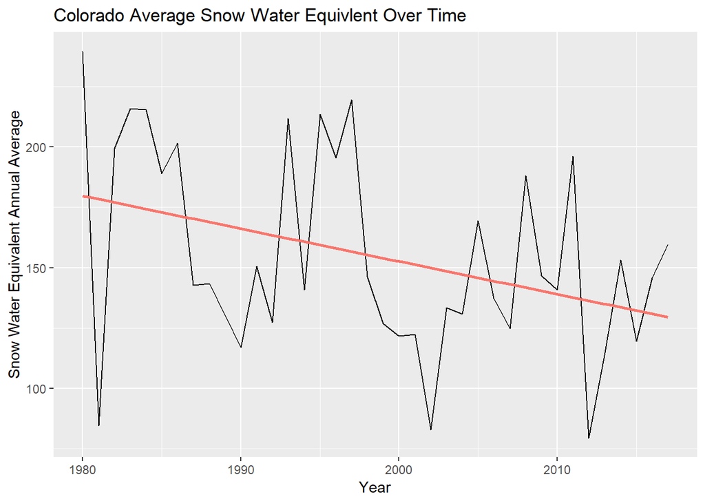

Figure 1

```
##
## Call:
## lm(formula = SWE.mm.Avg ~ Year, data = SWE.year.agg)
##
## Residuals:
##     Min      1Q  Median      3Q     Max
## -93.810 -26.661  -8.144  30.094  62.831
##
## Coefficients:
##              Estimate Std. Error t value Pr(>|t|)
## (Intercept) 2867.2886  1152.7831   2.487   0.0176 *
## Year          -1.3573     0.5768  -2.353   0.0242 *
## ---
## Signif. codes:  0 '***' 0.001 '**' 0.01 '*' 0.05 '.' 0.1 ' ' 1
##
## Residual standard error: 38.99 on 36 degrees of freedom
## Multiple R-squared:  0.1333, Adjusted R-squared:  0.1092
## F-statistic: 5.537 on 1 and 36 DF,  p-value: 0.0242
```

Figure 2

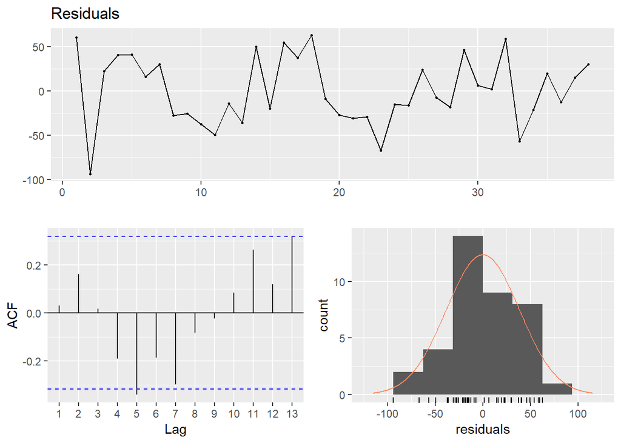

```
##
##  Breusch-Godfrey test for serial correlation of order up to 7
##
## data:  Residuals
## LM test = 10.276, df = 7, p-value = 0.1734
```

Figure 3

This shows residual data for the linear model of SWE annual mean over time

As seen in the analysis of the frequency data generated from the linear model, the cyclical nature shows up most strongly on the ACF plot, and the histogram is fairly normally distributed.

Because the year 1981 seems to be especially low, and the available data is less complete earlier in the dataset, I wanted to make sure the variation was not due to certain monitoring stations only used in earlier data collection that had a higher chance of collecting low data.

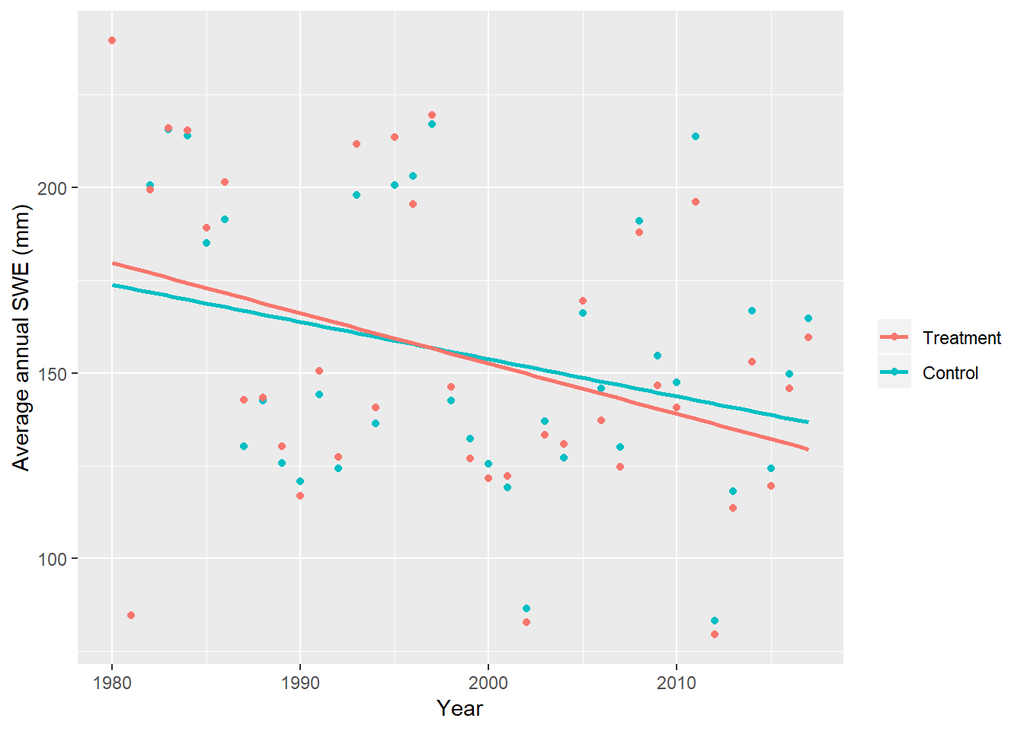

Figure 4

```
##
##  Pearson's Chi-squared test
##
## data:  PrecipData.outlier$SWE.mm.Avg.outlier and PrecipData.outlier$SWE.mm.Avg
## X-squared = 1406, df = 1369, p-value = 0.2378
```

# Atmospheric Carbon Dioxide concentration.

Using data gathered from NOAA Earth System Research Laboratory, average monthly $CO_{2}$ concentration in ppm is displayed over time.

Data was used from the Interplated column, as this column replaces missing values with an expected value.There was one missing value point in March of 1984, using the interpolated column gave the ability to have a more complete data set.

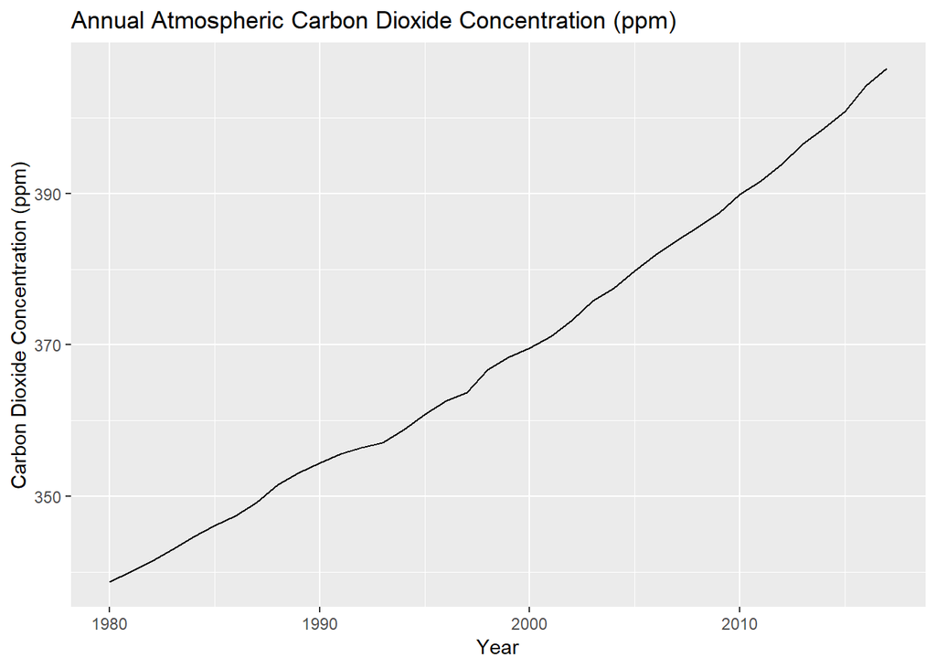

```
##
## Call:
## lm(formula = co2.ppm.Avg ~ Year, data = co2.year.agg)
##
## Residuals:
##     Min      1Q  Median      3Q     Max
## -2.7439 -1.5450 -0.0066  1.3493  4.2646
##
## Coefficients:
##               Estimate Std. Error t value Pr(>|t|)
## (Intercept) -3.210e+03  5.462e+01  -58.76   <2e-16 ***
## Year         1.791e+00  2.733e-02   65.52   <2e-16 ***
## ---
## Signif. codes:  0 '***' 0.001 '**' 0.01 '*' 0.05 '.' 0.1 ' ' 1
##
## Residual standard error: 1.847 on 36 degrees of freedom
## Multiple R-squared:  0.9917, Adjusted R-squared:  0.9915
## F-statistic:  4293 on 1 and 36 DF,  p-value: < 2.2e-16
```

Figure 5

Based on these linear models, I expect that $CO_{2}$ concentration to follow a linear equation of $y= 1.791x - 3210$.

Next we will look at what this means in context of snowfall.

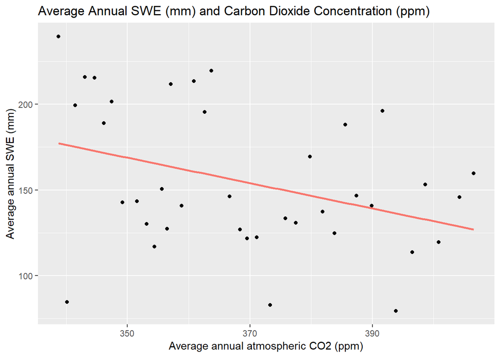

Figure 6

```
##
## Call:
## lm(formula = SWE.mm.Avg ~ co2.ppm.Avg, data = SWE.co2.year.agg)
##
## Residuals:
##     Min      1Q  Median      3Q     Max
## -91.591 -26.043  -9.087  32.261  62.468
##
## Coefficients:
##             Estimate Std. Error t value Pr(>|t|)
## (Intercept) 428.2543   118.9057   3.602 0.000947 ***
## co2.ppm.Avg  -0.7412     0.3216  -2.304 0.027077 *
## ---
## Signif. codes:  0 '***' 0.001 '**' 0.01 '*' 0.05 '.' 0.1 ' ' 1
##
## Residual standard error: 39.1 on 36 degrees of freedom
## Multiple R-squared:  0.1285, Adjusted R-squared:  0.1043
## F-statistic:  5.31 on 1 and 36 DF,  p-value: 0.02708
```

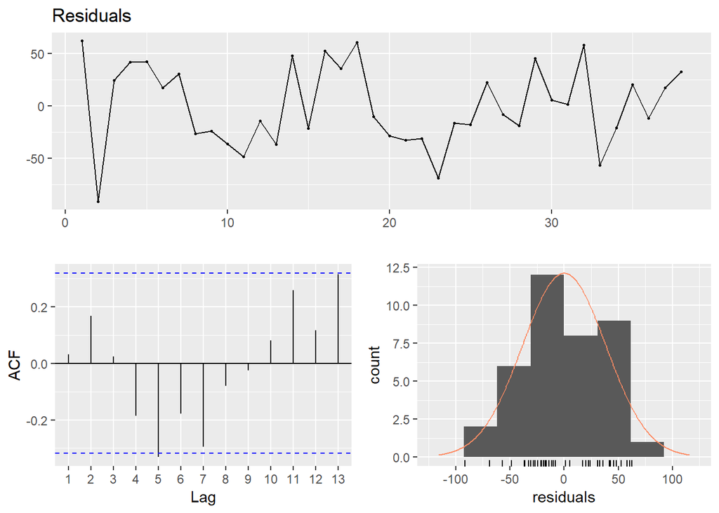

```
##
##  Breusch-Godfrey test for serial correlation of order up to 7
##
## data:  Residuals
## LM test = 9.7898, df = 7, p-value = 0.2008
```

Figure 7

This figure compares the average annual SWE data for all sites across CO, and the average annual $CO_{2}$ concntration in parts per million. This has been fitted with a linear line of best fit. Based on this plot, it shows there is a negative linear coorelation between $CO_{2}$ concentration and average annual SWE in Colorado. This means that as $CO_{2}$ concentration increases, SWE decreases.

Similarly to the previous plot showing only SWE data over time, the histogram generated from the residuals is fairly normally distributed.

Based on the linear model of past average annual snowfall and $CO_{2}$ concentration, I expect the SWE to follow a linear model of $y= -0.7412x + 428.2543$.

# Visitor Data

Because there was no publicly available data available for only the state of Colorado or to specific ski resorts, data made available by the National Ski Area Association which has released visitor numbers by region over time. Because Colorado is in the Rocky Mountain region and visitor data should coorelate to Colorado quite fairly, data was manually scraped from a reprt released by the National Ski Area Association. Visitor data is used to see if there is a correlation with visitors to SWE data. Thus showing if lower snowfall causes a decrease in visitors to ski areas.

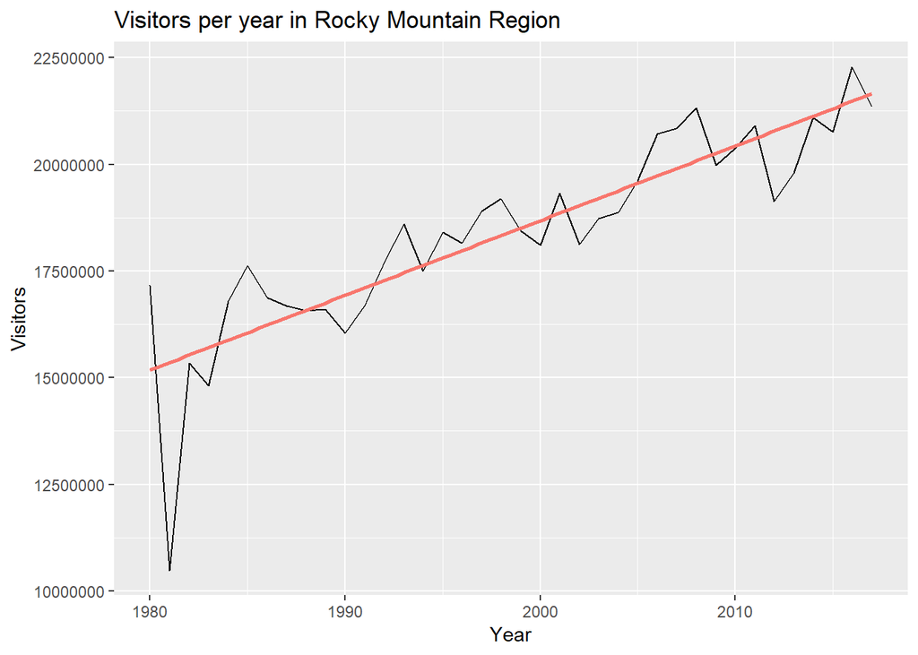

Figure 8

This plot showing the number of visitors each year in the Rocky Mountain region, shows that there is an overall increase in the number of visitors to ski areas, however there is shifts in the change for year over year.

# Tourism

Tourism data was manually scraped from the Colorado department of tourism, and the tourism numbers represent total tourism dollars spent in the mountain resort area of Colorado. Unlike the rest of the data, whcih started in 1980, this data was only available since 1996, therefore this is a smaller data set and does not contain as many years worth of data.

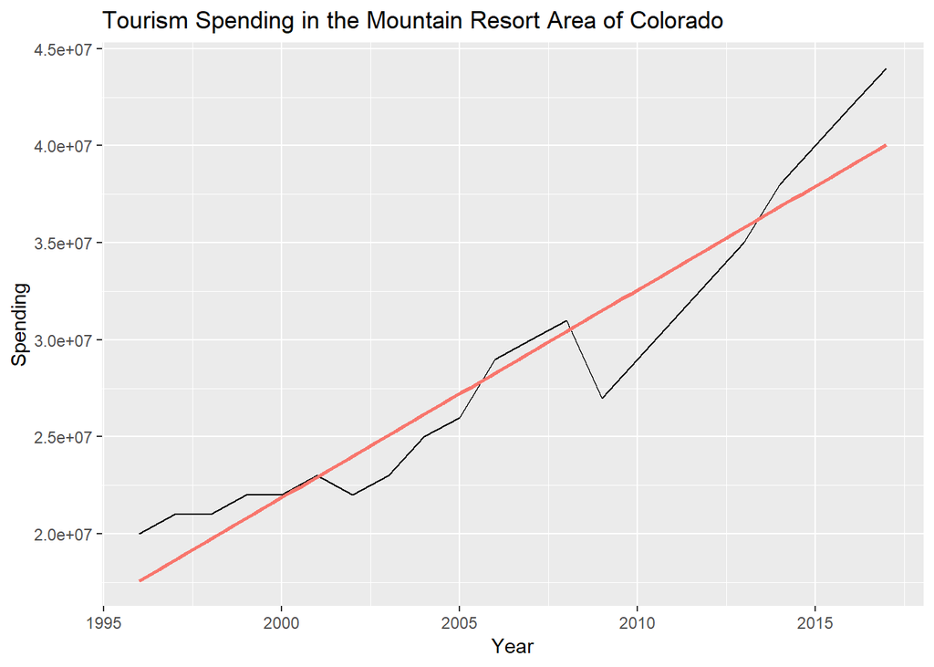

Figure 9

As shown in the plot, like visitor data, spending in the ski resort areas of Colorado also increased over time. However there does seem to be annual shifts from the average.

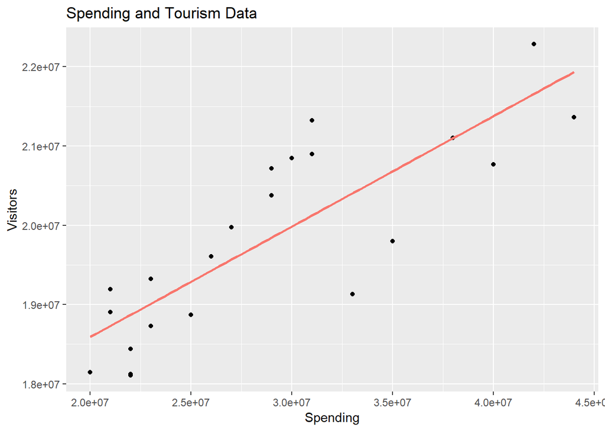

Figure 10

This is to show higher visitors generate higher tourism spending.

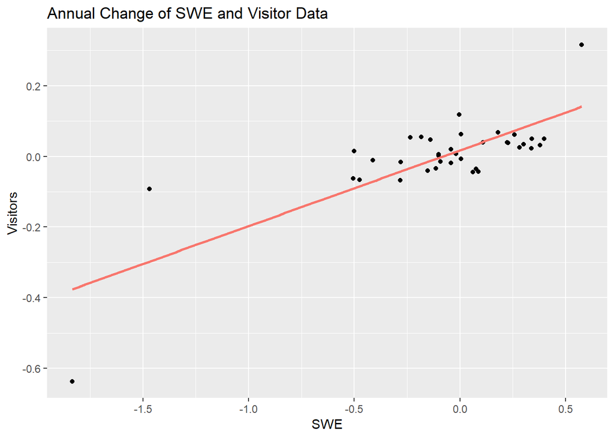

Figure 11

This plot shows the coorelation of change year over year for change in SWE and change in visitors to show a correlation in change in snowfall and a change in visitors to ski areas.

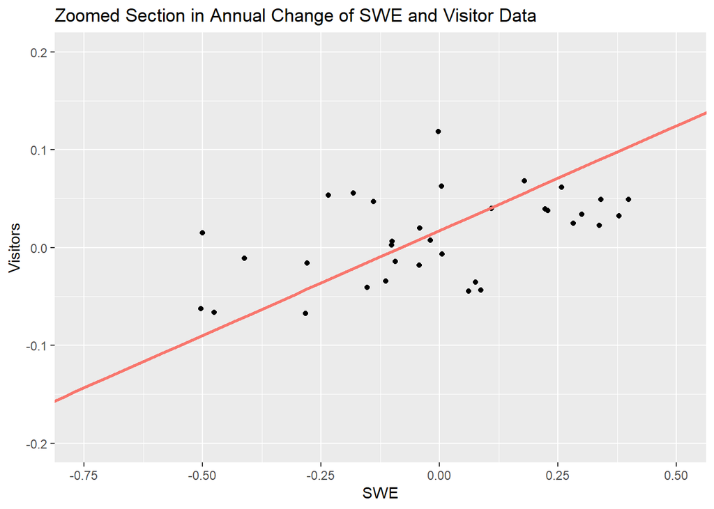

Figure 12

Because of the outliers in the previous plot are outliers, yet still viable data, this plot shows a zoomed in section of the main group.

```
##
## Call:
## lm(formula = Visitors ~ SWE, data = delta.all)
##
## Residuals:
##      Min       1Q   Median       3Q      Max
## -0.26077 -0.04111 -0.01100  0.02791  0.20483
##
## Coefficients:
##             Estimate Std. Error t value Pr(>|t|)
## (Intercept)  0.01737    0.01348   1.289    0.206
## SWE          0.21440    0.02896   7.404 1.16e-08 ***
## ---
## Signif. codes:  0 '***' 0.001 '**' 0.01 '*' 0.05 '.' 0.1 ' ' 1
##
## Residual standard error: 0.08061 on 35 degrees of freedom
## Multiple R-squared:  0.6103, Adjusted R-squared:  0.5992
## F-statistic: 54.82 on 1 and 35 DF,  p-value: 1.159e-08
```

Figure 13

These charts show the average annual change of SWE and Visitor data. This shows that there is a positive coorelation between the change in snowfall from the previous year and the amount of people who visit ski areas.

# Conclution

Based on the data presented the data do show that increasing $CO_{2}$ concentration in the atmosphere does have a negative effect on annual snowfall, and thus a negative effect on visitors to ski areas which in turn effects the amount of money spent on tourism in Colorado. Lawmakers in Colorado as well as individuals who enjoy winter sports and gain economic benefit from winter sports should me more mindful of the implications of increasing $CO_{2}$ concentration on Colorado’s ability to provide world class ski terrain for the future.